# iDEP: Investigating Differentially Expressed Genes

## If this site has contributed to your work, please cite our article:

Ge, S.X., Son, E.W. & Yao, R. iDEP: an integrated web application for differential expression and pathway analysis of RNA-Seq data. BMC Bioinformatics 19, 534 (2018). https://doi.org/10.1186/s12859-018-2486-6

## Summary

Read Counts data were analyzed using iDEP v2.4.4. The data was first filtered to remove reads below 0.5 CPM in at least 1 sample. Then the data was transformed with EdgeR using a pseudocount of 4. Missing values were imputed using geneMedian.

After mapping, there are 32833 unique genes in 158 samples. Of the 24127 genes passed filter, 24127 were converted to Ensembl/STRING gene IDs in our database. The remaining 0 genes were kept in the data using original IDs.

Differential expression analysis was performed using DESeq2 with an FDR cutoff of 0.1 and a minimum fold-change threshold of 2. Standard Wald test was used and independent filtering was enabled.

## Selected Comparison: Time_After_Treatment_min360-Time_After_Treatment_min0

Up-regulated genes: 237

Down-regulated genes: 475

## Top Up-regulated Genes

```r
if (!is.null(params$up_genes_table) && nrow(params$up_genes_table) > 0) {
  kbl(params$up_genes_table, escape = FALSE) %>%
    kable_classic(full_width = FALSE, html_font = "Cambria")
} else {
  print("No up-regulated genes found for this comparison.")
}
```

| Symbol | Ensembl ID | log2 FC | Adj. P-value | Description |
| --- | --- | --- | --- | --- |
| AT2G09785 | AT2G09785 | 25.062 | 1.10e-08 | NcRNA |
| AT1G04163 | AT1G04163 | 13.924 | 2.20e-03 | NcRNA |
| AT1G07500 | AT1G07500 | 10.986 | 9.24e-09 | Uncharacterized protein |
| AT1G05767 | AT1G05767 | 8.551 | 2.48e-04 | S-adenosyl-L-methionine-dependent methyltransferases superfamily protein |
| AT2G20500 | AT2G20500 | 4.399 | 9.69e-02 | Uncharacterized protein |
| ATCG00460 | ATCG00460 | 3.653 | 3.26e-04 |  |
| rps14 | ATCG00330 | 3.343 | 3.78e-08 |  |
| CYP82G1 | AT3G25180 | 3.322 | 8.05e-02 | Cytochrome P450, family 82, subfamily G, polypeptide 1 |
| AT1G07737 | AT1G07737 | 3.169 | 9.35e-02 | NcRNA |
| AT2G32160 | AT2G32160 | 3.076 | 2.30e-07 | S-adenosyl-L-methionine-dependent methyltransferases superfamily protein |
| AT2G35070 | AT2G35070 | 3.015 | 2.32e-02 | Uncharacterized protein |
| atpE | ATCG00470 | 2.993 | 1.06e-06 |  |
| AT5G44440 | AT5G44440 | 2.821 | 4.76e-02 | FAD-binding Berberine family protein |
| MT1B | AT5G56795 | 2.767 | 2.26e-04 | Metallothionein 1B |
| HB21 AT2G18550 | AT2G18550 | 2.748 | 1.56e-02 | Homeobox protein 21 |
| SAG29 | AT5G13170 | 2.695 | 3.00e-03 | Senescence-associated 29 |
| ANK | AT5G54610 | 2.603 | 5.69e-02 | Ankyrin |
| atpI | ATCG00150 | 2.592 | 2.66e-06 |  |
| CRK7 | AT4G23150 | 2.526 | 3.90e-02 | Cysteine-rich RLK (RECEPTOR-like protein kinase) 7 |
| OCT1 | AT1G73220 | 2.497 | 1.25e-03 | Organic cation/carnitine transporter1 |
| NIG1 | AT5G46830 | 2.489 | 7.67e-03 | Calcium-binding transcription factor NIG1 |
| AT5G53230 | AT5G53230 | 2.344 | 7.99e-02 |  |
| AT5G40800 | AT5G40800 | 2.332 | 1.35e-02 | Uncharacterized protein |
| AT2G07629 | AT2G07629 | 2.250 | 3.81e-02 | Uncharacterized protein |
| AT3G27250 | AT3G27250 | 2.227 | 1.64e-02 | Uncharacterized protein |
| AT3G27970 | AT3G27970 | 2.174 | 3.53e-02 | Exonuclease family protein |
| ndhC | ATCG00440 | 2.143 | 1.14e-04 |  |
| THAS1 | AT5G48010 | 2.038 | 1.20e-02 | Thalianol synthase 1 |
| AT1G22160 | AT1G22160 | 2.001 | 2.35e-05 | Senescence-associated family protein (DUF581) |
| ATMG01380 | ATMG01380 | 1.980 | 2.95e-02 |  |
| ATMG01280 | ATMG01280 | 1.966 | 8.64e-02 |  |
| rpl32 | ATCG01020 | 1.964 | 1.11e-03 |  |
| PAP1 AT1G56650 | AT1G56650 | 1.904 | 4.75e-02 | Production of anthocyanin pigment 1 |
| AT1G18990 | AT1G18990 | 1.901 | 2.70e-02 | Myosin-binding protein, putative (Protein of unknown function, DUF593) |
| AT1G76960 | AT1G76960 | 1.843 | 6.88e-02 | Uncharacterized protein |
| CYP705A12 | AT5G42580 | 1.836 | 1.14e-02 | Cytochrome P450, family 705, subfamily A, polypeptide 12 |
| SULTR1;3 | AT1G22150 | 1.834 | 5.74e-03 | Sulfate transporter 1 |
| MGDC | AT2G11810 | 1.827 | 3.85e-03 | Monogalactosyldiacylglycerol synthase type C |
| AT5G53048 | AT5G53048 | 1.825 | 2.62e-02 | NcRNA |
| FMO GS-OX2 | AT1G62540 | 1.819 | 1.57e-03 | Flavin-monooxygenase glucosinolate S-oxygenase 2 |
| bHLH38 | AT3G56970 | 1.814 | 4.29e-02 | Basic helix-loop-helix (bHLH) DNA-binding superfamily protein |
| AT1G11090 | AT1G11090 | 1.799 | 3.89e-02 | Alpha/beta-Hydrolases superfamily protein |
| AT1G26590 | AT1G26590 | 1.773 | 7.62e-03 | C2H2-like zinc finger protein |
| AT5G37980 | AT5G37980 | 1.771 | 1.52e-02 | Zinc-binding dehydrogenase family protein |
| CSLG1 | AT4G24010 | 1.763 | 9.75e-03 | Cellulose synthase like G1 |
| AT1G23110 | AT1G23110 | 1.747 | 9.41e-02 | Fold protein |
| CYP78A9 | AT3G61880 | 1.743 | 1.96e-03 | Cytochrome p450 78a9 |
| AT5G20790 | AT5G20790 | 1.736 | 3.50e-03 | Uncharacterized protein |
| PS2 AT1G73010 | AT1G73010 | 1.713 | 1.11e-02 | Inorganic pyrophosphatase 1 |
| AT2G22590 | AT2G22590 | 1.712 | 5.76e-02 | UDP-Glycosyltransferase superfamily protein |

## Top Down-regulated Genes

```r
if (!is.null(params$down_genes_table) && nrow(params$down_genes_table) > 0) {
  kbl(params$down_genes_table, escape = FALSE) %>%
    kable_classic(full_width = FALSE, html_font = "Cambria")
} else {
  print("No down-regulated genes found for this comparison.")
}
```

| Symbol | Ensembl ID | log2 FC | Adj. P-value | Description |
| --- | --- | --- | --- | --- |
| GMD1 | AT5G66280 | -10.441 | 3.77e-09 | GDP-D-mannose 4,6-dehydratase 1 |
| ATCG01000 | ATCG01000 | -10.199 | 2.65e-02 |  |
| AT1G09053 | AT1G09053 | -8.890 | 1.99e-03 | NcRNA |
| AT5G51190 | AT5G51190 | -8.291 | 1.03e-07 | Integrase-type DNA-binding superfamily protein |
| CRU3 | AT4G28520 | -7.568 | 1.24e-02 | Cruciferin 3 |
| AT1G33760 | AT1G33760 | -5.002 | 1.35e-03 | Integrase-type DNA-binding superfamily protein |
| AT1G15330 | AT1G15330 | -4.926 | 5.19e-04 | Cystathionine beta-synthase (CBS) protein |
| PAP85 | AT3G22640 | -4.708 | 1.25e-02 | Cupin family protein |
| CRA1 | AT5G44120 | -4.576 | 8.61e-03 | RmlC-like cupins superfamily protein |
| AT2G42560 | AT2G42560 | -4.574 | 3.53e-02 | Late embryosis abundant domain-containing protein / LEA domain-containing protein |
| OLEO2 | AT5G40420 | -4.479 | 5.79e-02 | Oleosin 2 |
| AT3G15450 | AT3G15450 | -4.021 | 7.73e-06 | Aluminum induced protein with YGL and LRDR motifs |
| ZAT7 | AT3G46090 | -3.896 | 5.48e-05 | C2H2 and C2HC zinc fingers superfamily protein |
| RTFL12 | AT4G13395 | -3.782 | 4.20e-04 | ROTUNDIFOLIA like 12 |
| PP2-B13 | AT1G56240 | -3.694 | 1.17e-03 | Phloem protein 2-B13 |
| DIN11 | AT3G49620 | -3.584 | 2.86e-05 | 2-oxoglutarate (2OG) and Fe(II)-dependent oxygenase superfamily protein |
| JAZ7 | AT2G34600 | -3.578 | 2.94e-03 | Jasmonate-zim-domain protein 7 |
| CML38 | AT1G76650 | -3.469 | 1.14e-05 | Calmodulin-like 38 |
| AT3G21320 | AT3G21320 | -3.459 | 2.13e-02 | EARLY FLOWERING protein |
| AT1G15125 | AT1G15125 | -3.415 | 8.13e-06 | S-adenosyl-L-methionine-dependent methyltransferases superfamily protein |
| AT1G07135 | AT1G07135 | -3.394 | 4.70e-07 | Glycine-rich protein |
| CYP706A2 | AT4G22710 | -3.393 | 7.59e-04 | Cytochrome P450, family 706, subfamily A, polypeptide 2 |
| AT3G62950 | AT3G62950 | -3.372 | 1.09e-03 | Thioredoxin superfamily protein |
| AT5G06235 | AT5G06235 | -3.325 | 1.20e-02 | NcRNA |
| WRKY40 | AT1G80840 | -3.302 | 1.68e-04 | WRKY DNA-binding protein 40 |
| ERF2 | AT5G47220 | -3.298 | 1.51e-06 | Ethylene responsive element binding factor 2 |
| AT3G54940 | AT3G54940 | -3.253 | 4.54e-02 | Papain family cysteine protease |
| AT2G32200 | AT2G32200 | -3.073 | 6.45e-03 | Cysteine-rich/transmembrane domain A-like protein |
| MIOX4 | AT4G26260 | -3.073 | 3.50e-03 | Myo-inositol oxygenase 4 |
| AT5G44310 | AT5G44310 | -3.046 | 9.69e-02 | Late embryosis abundant protein (LEA) family protein |
| AT1G56060 | AT1G56060 | -3.015 | 2.49e-02 | Cysteine-rich/transmembrane domain protein B |
| AT1G66090 | AT1G66090 | -3.010 | 1.22e-05 | Disease resistance protein (TIR-NBS class) |
| CBF1 | AT4G25490 | -2.988 | 3.93e-02 | C-repeat/DRE binding factor 1 |
| AT4G36850 | AT4G36850 | -2.981 | 2.12e-04 | PQ-loop repeat family protein / transmembrane family protein |
| HSPRO2 | AT2G40000 | -2.980 | 2.28e-06 | Ortholog of sugar beet HS1 PRO-1 2 |
| TCH3 | AT2G41100 | -2.960 | 2.62e-05 | Calcium-binding EF hand family protein |
| TCH4 | AT5G57560 | -2.903 | 3.94e-05 | Xyloglucan endotransglucosylase/hydrolase family protein |
| HSD5 | AT4G10020 | -2.895 | 8.86e-02 | Hydroxysteroid dehydrogenase 5 |
| DIN10 | AT5G20250 | -2.895 | 5.89e-05 | Raffinose synthase family protein |
| ERF13 | AT2G44840 | -2.867 | 1.80e-03 | Ethylene-responsive element binding factor 13 |
| AT1G02620 | AT1G02620 | -2.846 | 1.50e-02 | Ras-related small GTP-binding family protein |
| AT1G35210 | AT1G35210 | -2.837 | 3.18e-04 | Uncharacterized protein |
| STZ | AT1G27730 | -2.827 | 7.62e-06 | Salt tolerance zinc finger |
| AT1G15010 | AT1G15010 | -2.826 | 3.24e-03 | Mediator of RNA polymerase II transcription subunit |
| ERF104 | AT5G61600 | -2.744 | 5.71e-09 | Ethylene response factor 104 |
| AT1G21326 | AT1G21326 | -2.714 | 7.81e-04 | VQ motif-containing protein |
| AT2G41750 | AT2G41750 | -2.709 | 4.54e-02 | DTW domain-containing protein |
| BCB | AT5G20230 | -2.694 | 6.60e-04 | Blue-copper-binding protein |
| DREB26 | AT1G21910 | -2.627 | 1.18e-05 | Integrase-type DNA-binding superfamily protein |
| XTH25 | AT5G57550 | -2.579 | 3.41e-02 | Xyloglucan endotransglucosylase/hydrolase 25 |

## DEG Heatmap

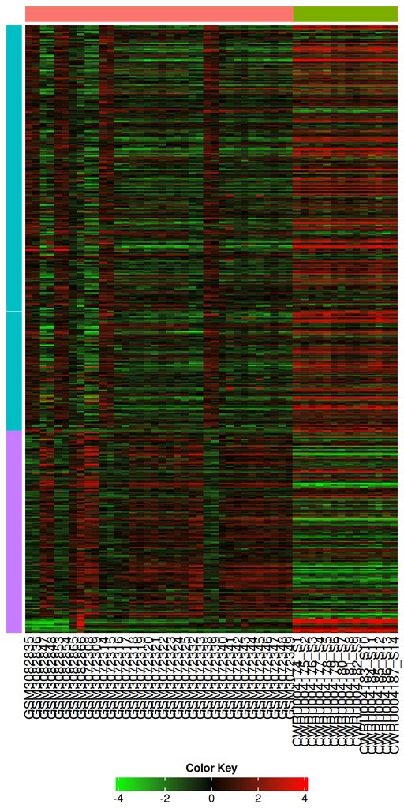

```r
if (!is.null(params$heat_data) && !is.null(params$heat_bar)) {
  heat_colors <- unlist(strsplit(params$heatmap_color_select, "-"))

  deg_heatmap(
    df = params$heat_data,
    bar = params$heat_bar,
    heatmap_color_select = heat_colors,
    cluster_rows = FALSE
  )
}
```

## Volcano Plot

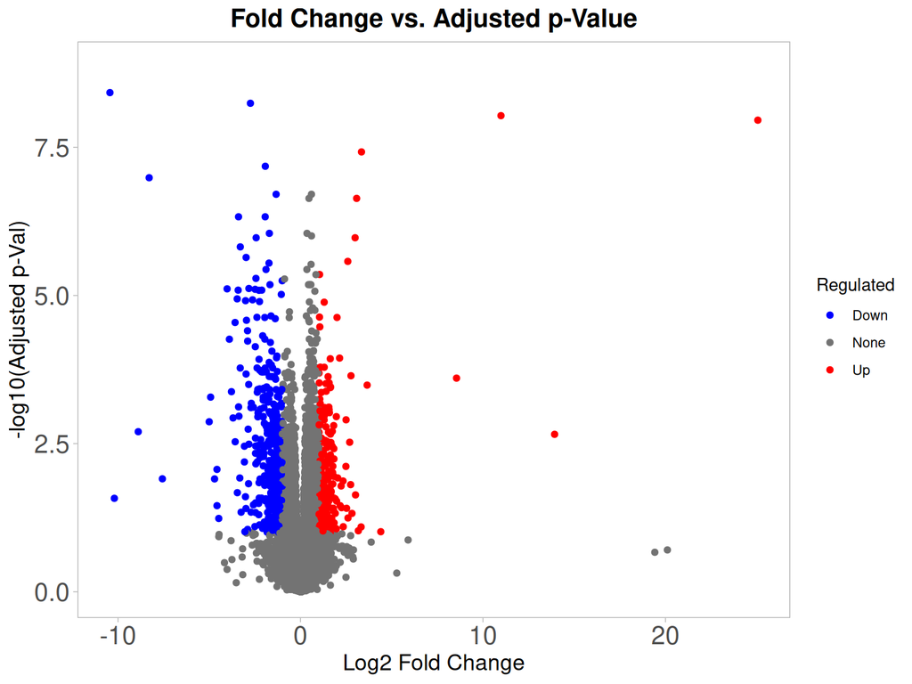

```r
if (!is.null(params$vol_data) && !is.null(params$vol_data$data)) {
  p <- plot_volcano(
    data = params$vol_data$data,
    plot_colors = params$plot_colors,
    anotate_genes = params$gene_labels_volcano
  )
  p <- refine_ggplot2(
    p = p,
    gridline = params$plot_grid_lines,
    ggplot2_theme = params$ggplot2_theme
  )
  print(p)
}
```